# **Predicting Used Car Prices**

# Part 1: Exploratory Data Analysis

**Background:**

The Indian market is currently witnessing a significant surge in the demand for used cars. This trend has been fueled by a slowdown in new car sales, prompting consumers to turn towards the pre-owned vehicle market. Over the past few years, the size of this market has not only grown but has also surpassed that of new cars. Cars4U, an emerging tech startup, is strategically positioning itself to capitalize on these market dynamics.

The pricing and supply of new cars are generally predictable, controlled by Original Equipment Manufacturers (OEMs), with the only variations occurring due to dealership-level discounts at the final stage of the customer journey. However, the used car market operates differently. It is characterized by significant uncertainties in both pricing and supply. The valuation of a used car can be influenced by multiple factors including mileage, model year, brand, and overall condition. For sellers, setting an accurate price is challenging yet crucial for market competitiveness.

**Objective:**

The primary goal of this data sience project is to develop a robust pricing model that can accurately predict the prices of used cars. Such a model will not only facilitate fair market transactions but also enable Cars4U to implement differential pricing strategies that could drive profitability and market growth.

1. Introduction
   - Data dictionary
   - Set-up
   - Initial observations
2. Univariate analysis
   - Numerical data
   - Categorical
3. Multivariate analysis
4. Feature engineering
5. Conclusion

# **1. Introduction**

## 1.1 Data Dictionary

| Variable | Description |
| --- | --- |
| **S.No.** | Serial Number |
| **Name** | Name of the car which includes Brand name and Model name |
| **Location** | The location in which the car is being sold or is available for purchase (Cities) |
| **Year** | Manufacturing year of the car |
| **KM_driven** | The total kilometers driven in the car by the previous owner(s) in KM |
| **Fuel** | The type of fuel used by the car (Petrol, Diesel, Electric, CNG, LPG) |
| **Transmission** | The type of transmission used by the car (Automatic / Manual) |
| **Owner** | Number of previous owners |
| **Mileage** | The standard mileage offered by the car company in kmpl or km/kg |
| **Engine** | The displacement volume of the engine in CC |
| **Power** | The maximum power of the engine in bhp |
| **Seats** | The number of seats in the car |
| **New_Price** | The price of a new car of the same model in INR 100,000 |
| **Price** | The price of a used car in INR 100,000 (Target Variable) |

## 1.2 Set up

**Libraries**

```python
import pandas as pd
import numpy as np
import matplotlib.pyplot as plt
import seaborn as sns
import re
```

**Load the dataset**

```python
# Load the data set
input_df = pd.read_csv("used_cars.csv")
input_df.shape
```

```
(7253, 14)
```

## 1.3 Initial observations

- We have a rich data set that contains information about 7253 used cars
  - However, we have price data for only 6019 of them. Price data is our target variable
  - We have New_price data for 1006 cars, which is only 14% of the entries.
- These cars were produced between 1996 and 2019
- Average price of a used car is INR 948,000
- Most of the cars have 5 seats, but there are also coupes with 2 seats and mini-buses with 10 seats
- We will need to take a closer look at some of the data points:
  - Mileage for some cars is 0, which does not make sense
  - Maximum value for kilometers driven is 6,5 million, which is an extreme outlier

**Changes**

- I delete the 'S.No.' column because it carries no informational value
- Also, I optimize the names of 3 variables for coding efficiency:
  - rename Fuel_Type to Fuel, Owner_Type to Owner, Kilometers_Driven to KM_Driven

**First five rows of the data set**

```python
input_df.head()
```

|  | S.No. | Name | Location | Year | Kilometers_Driven | Fuel_Type | Transmission | Owner_Type | Mileage | Engine | Power | Seats | New_price | Price |
| --- | --- | --- | --- | --- | --- | --- | --- | --- | --- | --- | --- | --- | --- | --- |
| 0 | 0 | Maruti Wagon R LXI CNG | Mumbai | 2010 | 72000 | CNG | Manual | First | 26.60 | 998.0 | 58.16 | 5.0 | NaN | 1.75 |
| 1 | 1 | Hyundai Creta 1.6 CRDi SX Option | Pune | 2015 | 41000 | Diesel | Manual | First | 19.67 | 1582.0 | 126.20 | 5.0 | NaN | 12.50 |
| 2 | 2 | Honda Jazz V | Chennai | 2011 | 46000 | Petrol | Manual | First | 18.20 | 1199.0 | 88.70 | 5.0 | 8.61 | 4.50 |
| 3 | 3 | Maruti Ertiga VDI | Chennai | 2012 | 87000 | Diesel | Manual | First | 20.77 | 1248.0 | 88.76 | 7.0 | NaN | 6.00 |
| 4 | 4 | Audi A4 New 2.0 TDI Multitronic | Coimbatore | 2013 | 40670 | Diesel | Automatic | Second | 15.20 | 1968.0 | 140.80 | 5.0 | NaN | 17.74 |

**Statistical summary of numeric variables**

```python
input_df.describe().T
```

|  | count | mean | std | min | 25% | 50% | 75% | max |
| --- | --- | --- | --- | --- | --- | --- | --- | --- |
| S.No. | 7253.0 | 3626.000000 | 2093.905084 | 0.00 | 1813.000 | 3626.00 | 5439.0000 | 7252.00 |
| Year | 7253.0 | 2013.365366 | 3.254421 | 1996.00 | 2011.000 | 2014.00 | 2016.0000 | 2019.00 |
| Kilometers_Driven | 7253.0 | 58699.063146 | 84427.720583 | 171.00 | 34000.000 | 53416.00 | 73000.0000 | 6500000.00 |
| Mileage | 7251.0 | 18.141580 | 4.562197 | 0.00 | 15.170 | 18.16 | 21.1000 | 33.54 |
| Engine | 7207.0 | 1616.573470 | 595.285137 | 72.00 | 1198.000 | 1493.00 | 1968.0000 | 5998.00 |
| Power | 7078.0 | 112.765214 | 53.493553 | 34.20 | 75.000 | 94.00 | 138.1000 | 616.00 |
| Seats | 7200.0 | 5.280417 | 0.809277 | 2.00 | 5.000 | 5.00 | 5.0000 | 10.00 |
| New_price | 1006.0 | 22.779692 | 27.759344 | 3.91 | 7.885 | 11.57 | 26.0425 | 375.00 |
| Price | 6019.0 | 9.479468 | 11.187917 | 0.44 | 3.500 | 5.64 | 9.9500 | 160.00 |

**Number of missing values in each column:**

```python
input_df.isnull().sum()
```

```
S.No.                   0
Name                    0
Location                0
Year                    0
Kilometers_Driven       0
Fuel_Type               0
Transmission            0
Owner_Type              0
Mileage                 2
Engine                 46
Power                 175
Seats                  53
New_price            6247
Price                1234
dtype: int64
```

**Data types**

```python
input_df.info()
```

```
<class 'pandas.core.frame.DataFrame'>
RangeIndex: 7253 entries, 0 to 7252
Data columns (total 14 columns):
 #   Column             Non-Null Count  Dtype
---  ------             --------------  -----
 0   S.No.              7253 non-null   int64
 1   Name               7253 non-null   object
 2   Location           7253 non-null   object
 3   Year               7253 non-null   int64
 4   Kilometers_Driven  7253 non-null   int64
 5   Fuel_Type          7253 non-null   object
 6   Transmission       7253 non-null   object
 7   Owner_Type         7253 non-null   object
 8   Mileage            7251 non-null   float64
 9   Engine             7207 non-null   float64
 10  Power              7078 non-null   float64
 11  Seats              7200 non-null   float64
 12  New_price          1006 non-null   float64
 13  Price              6019 non-null   float64
dtypes: float64(6), int64(3), object(5)
memory usage: 793.4+ KB
```

**Basic summary statistics of categorical variables:**

```python
input_df.describe(include='object')
```

|  | Name | Location | Fuel_Type | Transmission | Owner_Type |
| --- | --- | --- | --- | --- | --- |
| count | 7253 | 7253 | 7253 | 7253 | 7253 |
| unique | 2041 | 11 | 5 | 2 | 4 |
| top | Mahindra XUV500 W8 2WD | Mumbai | Diesel | Manual | First |
| freq | 55 | 949 | 3852 | 5204 | 5952 |

```python
cat_cols = input_df.select_dtypes(include=['object']).columns
for column in cat_cols:
    print("For column:", column)
    print(input_df[column].unique())
    print('-'*50)
```

```
For column: Name
['Maruti Wagon R LXI CNG' 'Hyundai Creta 1.6 CRDi SX Option'
 'Honda Jazz V' ... 'Ford EcoSport 1.5 Petrol Ambiente'
 'Jeep Compass 1.4 Sport' 'Hyundai Elite i20 Magna Plus']
--------------------------------------------------
For column: Location
['Mumbai' 'Pune' 'Chennai' 'Coimbatore' 'Hyderabad' 'Jaipur' 'Kochi'
 'Kolkata' 'Delhi' 'Bangalore' 'Ahmedabad']
--------------------------------------------------
For column: Fuel_Type
['CNG' 'Diesel' 'Petrol' 'LPG' 'Electric']
--------------------------------------------------
For column: Transmission
['Manual' 'Automatic']
--------------------------------------------------
For column: Owner_Type
['First' 'Second' 'Fourth & Above' 'Third']
--------------------------------------------------
```

```python
clean_df = input_df.copy() # Make a copy of input_df
clean_df.drop(['S.No.'], axis=1, inplace=True) # Remove the S.No. column from clean_df
# Rename columns in clean_df to make them more readable
clean_df.rename(columns={'Fuel_Type': 'Fuel', 'Owner_Type': 'Owner', 'Kilometers_Driven': 'KM_driven'}, inplace=True)
```

Number of unique values in each column

```python
clean_df.nunique()
```

```
Name            2041
Location          11
Year              23
KM_driven       3660
Fuel               5
Transmission       2
Owner              4
Mileage          438
Engine           150
Power            383
Seats              8
New_price        625
Price           1373
dtype: int64
```

# **2. Univariate analysis**

Univariate analysis is used to explore each variable in a data set, separately. It looks at the range of values, as well as the central tendency of the values. It can be done for both numerical and categorical variables.

## 2.1 Numerical data

Histograms and box plots help to visualize and describe numerical data. We use box plot and histogram to analyse the numerical columns. First, I write a function that will help me create a boxplot and histogram for any input numerical variable. This function takes the numerical column as the input and returns the boxplots and histograms for the variable.

```python
def histogram_boxplot(feature, figsize=(12, 8), bins=50, title=""):
    """
    Boxplot and histogram combined
    feature: 1-d feature array
    figsize: size of fig (default (15, 10))
    bins: number of bins (default 50)
    title: Title of the figure (default is empty for flexibility)
    """
    f2, (ax_box2, ax_hist2) = plt.subplots(2,  # Number of rows of the subplot grid
                                           sharex=True,  # X-axis will be shared among all subplots
                                           gridspec_kw={"height_ratios": (.25, .75)},
                                           figsize=figsize)  # Creating the 2 subplots

    sns.boxplot(x=feature, ax=ax_box2, showmeans=True, color='violet')  # Boxplot with a symbol for mean
    sns.histplot(x=feature, kde=False, ax=ax_hist2, bins=bins, color="blue")  # For histogram

    ax_hist2.axvline(np.mean(feature), color='green', linestyle='--')  # Add mean to the histogram
    ax_hist2.axvline(np.median(feature), color='black', linestyle='-')  # Add median to the histogram

    if title:  # Only set the title if one is provided
        plt.suptitle(title)
    plt.show()
```

### `KM_driven` - kilometers driven

- Examine and treat the extreme outlier
  - A car manufactured as recently as 2017 registering 6,5 million under kilometers driven is near impossible. The car would need to drive 8900 km everyday in order to reach 6,5 million in 2 years.
  - It can be considered as data entry error so we can remove this value/entry from data.
- Create histogram and boxplot visualizations to study the distribution of KM_driven
- Kilometers_Driven is highly right-skewed
- Apply log transformation:
  - Typically statistical and machine learning models assume that the data is normally distributed. We use log transformation, which is commonly used for right-skewed distributions. It helps compress large values more than smaller values, thereby pulling the tail in.

**Sort the dataset in 'descending' order based on 'Kilometers_Driven':**

```python
clean_df.sort_values(['KM_driven'], ascending=False ).head(10)
```

|  | Name | Location | Year | KM_driven | Fuel | Transmission | Owner | Mileage | Engine | Power | Seats | New_price | Price |
| --- | --- | --- | --- | --- | --- | --- | --- | --- | --- | --- | --- | --- | --- |
| 2328 | BMW X5 xDrive 30d M Sport | Chennai | 2017 | 6500000 | Diesel | Automatic | First | 15.97 | 2993.0 | 258.00 | 5.0 | NaN | 65.00 |
| 340 | Skoda Octavia Ambition Plus 2.0 TDI AT | Kolkata | 2013 | 775000 | Diesel | Automatic | First | 19.30 | 1968.0 | 141.00 | 5.0 | NaN | 7.50 |
| 1860 | Volkswagen Vento Diesel Highline | Chennai | 2013 | 720000 | Diesel | Manual | First | 20.54 | 1598.0 | 103.60 | 5.0 | NaN | 5.90 |
| 358 | Hyundai i10 Magna 1.2 | Chennai | 2009 | 620000 | Petrol | Manual | First | 20.36 | 1197.0 | 78.90 | 5.0 | NaN | 2.70 |
| 2823 | Volkswagen Jetta 2013-2015 2.0L TDI Highline AT | Chennai | 2015 | 480000 | Diesel | Automatic | First | 16.96 | 1968.0 | 138.03 | 5.0 | NaN | 13.00 |
| 3092 | Honda City i VTEC SV | Kolkata | 2015 | 480000 | Petrol | Manual | First | 17.40 | 1497.0 | 117.30 | 5.0 | NaN | 5.00 |
| 4491 | Hyundai i20 Magna Optional 1.2 | Bangalore | 2013 | 445000 | Petrol | Manual | First | 18.50 | 1197.0 | 82.90 | 5.0 | NaN | 4.45 |
| 6921 | Maruti Swift Dzire Tour LDI | Jaipur | 2012 | 350000 | Diesel | Manual | First | 23.40 | 1248.0 | 74.00 | 5.0 | NaN | NaN |
| 3649 | Tata Indigo LS | Jaipur | 2008 | 300000 | Diesel | Manual | First | 17.00 | 1405.0 | 70.00 | 5.0 | NaN | 1.00 |
| 1528 | Toyota Innova 2.5 G (Diesel) 8 Seater BS IV | Hyderabad | 2005 | 299322 | Diesel | Manual | First | 12.80 | 2494.0 | 102.00 | 8.0 | NaN | 4.00 |

**Removing the 'row' at index 2328**

```python
clean_df.drop(index = 2328, inplace = True) # the outlier row
```

**Plot histogram and box-plot for 'KM_driven'**

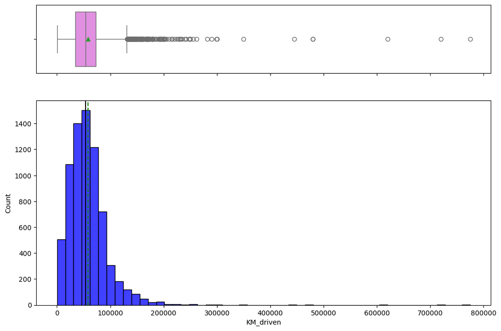

```python
histogram_boxplot(clean_df['KM_driven'])
```

**Apply log transformation and check the histplot again**

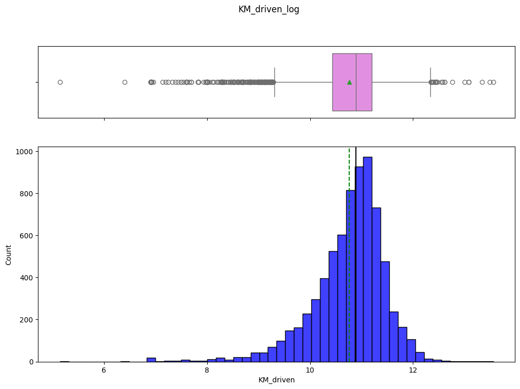

```python
KM_driven_log = clean_df['KM_driven']
histogram_boxplot(np.log(KM_driven_log), title="KM_driven_log")
```

### `Price` variable

**Histogram and box-plot for 'Price'**

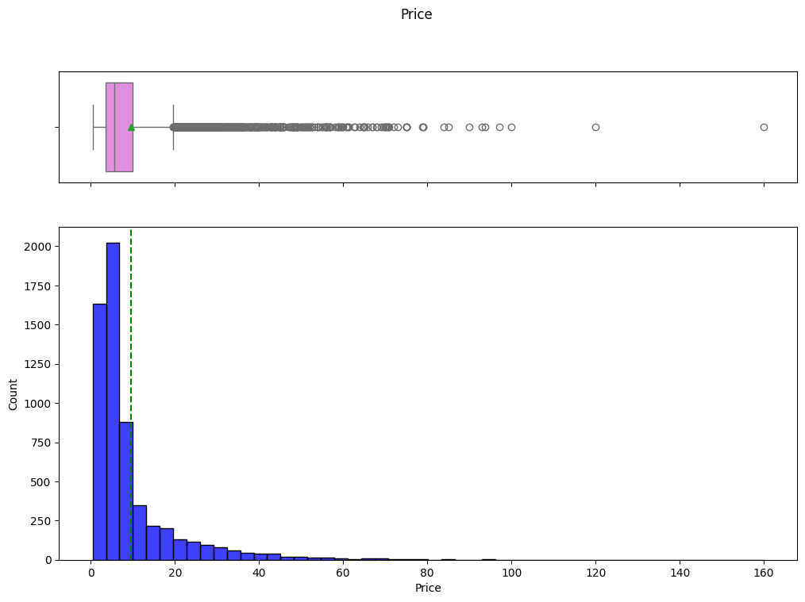

```python
histogram_boxplot(clean_df['Price'], title = 'Price')
```

**Histogram and box-plot for 'Price_log'**

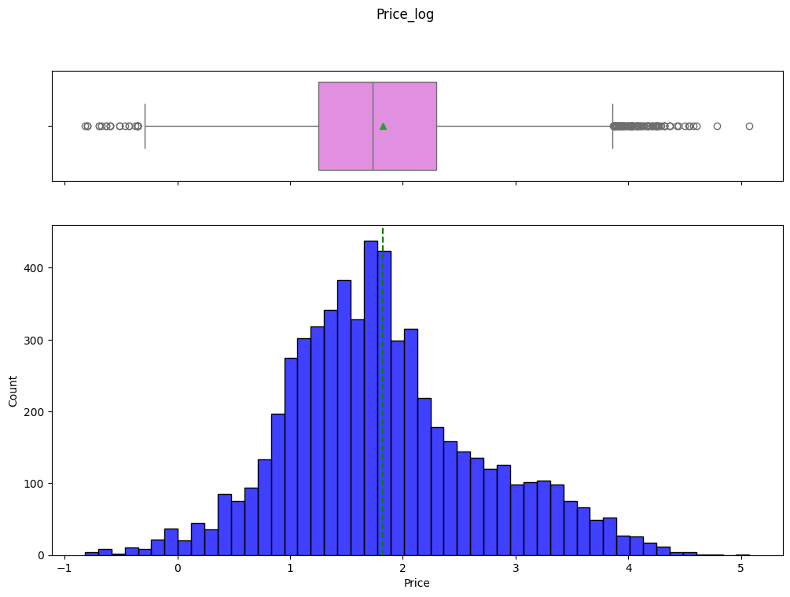

```python
Price_log = clean_df['Price']
histogram_boxplot(np.log(Price_log), title="Price_log")
```

### `Mileage` variable

- Mileage of cars can not be 0, so we should treat 0's as missing values. We will do it in the Feature Engineering part.

**Sort the dataset in 'ascending' order using the feature 'Mileage':**

```python
clean_df.sort_values(['Mileage'], ascending=True ).head(5)
```

|  | Name | Location | Year | KM_driven | Fuel | Transmission | Owner | Mileage | Engine | Power | Seats | New_price | Price |
| --- | --- | --- | --- | --- | --- | --- | --- | --- | --- | --- | --- | --- | --- |
| 2597 | Hyundai Santro Xing XP | Pune | 2007 | 70000 | Petrol | Manual | First | 0.0 | 1086.0 | NaN | 5.0 | NaN | 1.12 |
| 2343 | Hyundai Santro AT | Hyderabad | 2006 | 74483 | Petrol | Automatic | First | 0.0 | 999.0 | NaN | 5.0 | NaN | 2.30 |
| 5270 | Honda City 1.5 GXI | Bangalore | 2002 | 53000 | Petrol | Manual | Second | 0.0 | NaN | NaN | NaN | NaN | 1.85 |
| 424 | Volkswagen Jetta 2007-2011 1.9 L TDI | Hyderabad | 2010 | 42021 | Diesel | Manual | First | 0.0 | 1968.0 | NaN | 5.0 | NaN | 5.45 |
| 6857 | Land Rover Freelander 2 TD4 SE | Mumbai | 2011 | 87000 | Diesel | Automatic | First | 0.0 | 2179.0 | 115.0 | 5.0 | NaN | NaN |

**Number of rows where Mileage is 0:**

```python
clean_df[clean_df['Mileage'] == 0].shape[0]
```

```
81
```

```python
# number of rows where Mileage is 0 and Engine is missing
print('Number of rows where Mileage is 0 and Engine is missing:', clean_df[(clean_df['Mileage'] == 0) & (clean_df['Engine'].isnull())].shape[0])
```

```
Number of rows where Mileage is 0 and Engine is missing: 12
```

```python
clean_df['Mileage'] = clean_df['Mileage'].replace(0, np.nan)
```

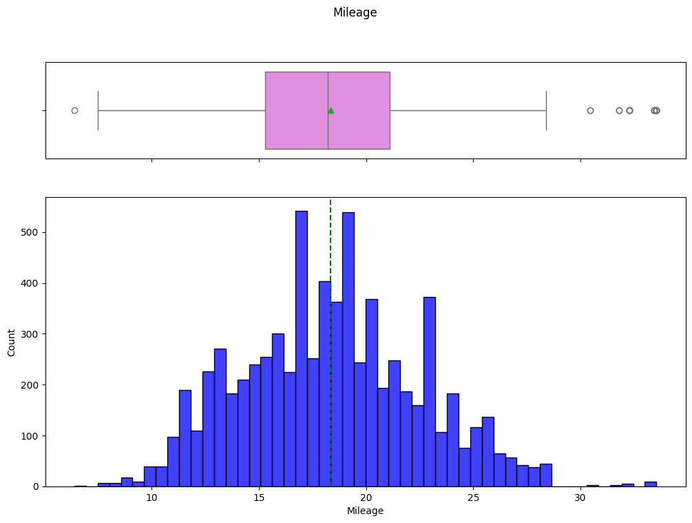

```python
histogram_boxplot(clean_df['Mileage'], title ="Mileage")
```

**Histogram**:

**Boxplot**:

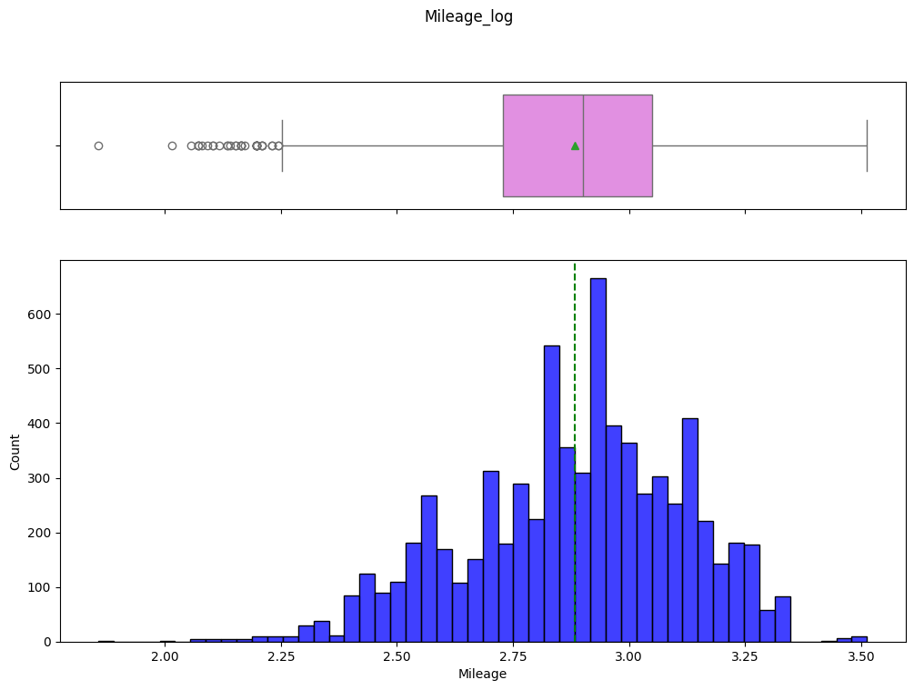

```python
Mileage_log = clean_df['Mileage']
histogram_boxplot(np.log(Mileage_log), title="Mileage_log")
```

### `Engine` variable

- As we can see from below output in all cases where Engine is missing power is also missing. Consequently, we cannot use 'Power' values to impute the missing 'Engine' values.

```python
print('Number of missing values in the Engine column:', clean_df['Engine'].isnull().sum())
print('Number of rows where both Engine and Power are missing:', clean_df[(clean_df['Engine'].isnull()) & (clean_df['Power'].isnull())].shape[0])
```

```
Number of missing values in the Engine column: 46
Number of rows where both Engine and Power are missing: 46
```

- Skewness: The histogram shows a right-skewed distribution. This is evident from the concentration of bars on the left side of the histogram and the long tail extending towards the right. This skewness indicates that there are a significant number of cars with smaller engine sizes, and a few cars with much larger engine sizes.
- Outliers: The boxplot displays numerous outliers on the right side of the box. These outliers are significantly higher than the main cluster of data, suggesting some cars have exceptionally high engine sizes compared to the rest.

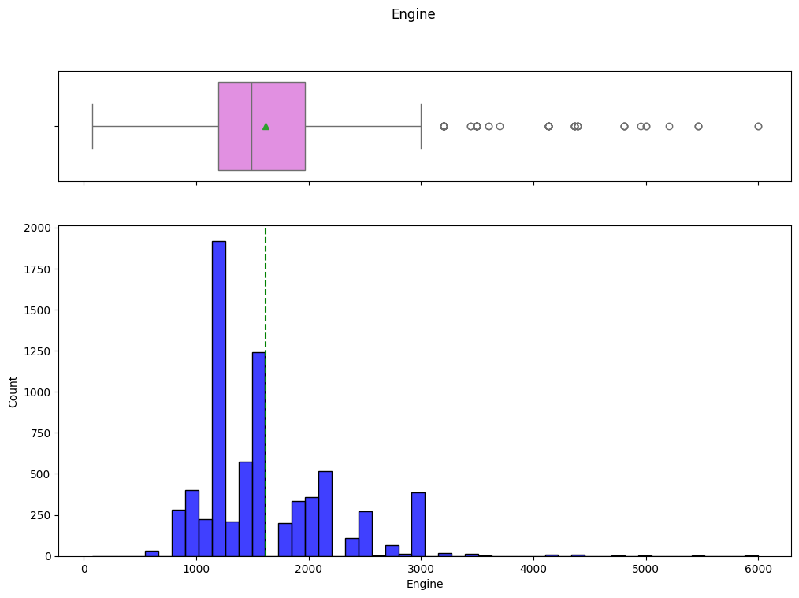

```python
histogram_boxplot(clean_df['Engine'], title = 'Engine')
```

**Engine_log**

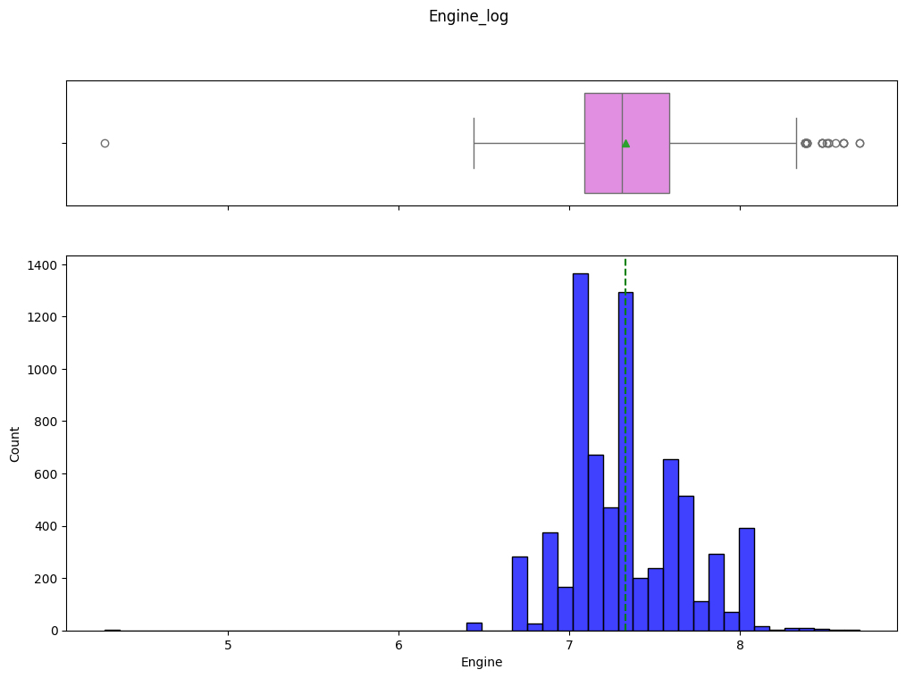

```python
Engine_log = clean_df['Engine']
histogram_boxplot(np.log(Engine_log), title="Engine_log")
```

The countplot of the log-transformed Engine values indicate that the transformation has improved the distribution of the data, but it still presents some challenges:

- Multi-modal Distribution: The log-transformed histogram shows a multi-modal distribution, which means there are multiple peaks. This suggests that there are distinct groups of cars with different engine sizes that behave differently.
- Presence of Peaks and Tails: There are still evident peaks and a tail, particularly towards the higher end of the log scale.

Since it is a step in the right direction, I will create a new Engine_log variable. In the model construction phase (next notebook) we will return to this issue.

### `Power` variable

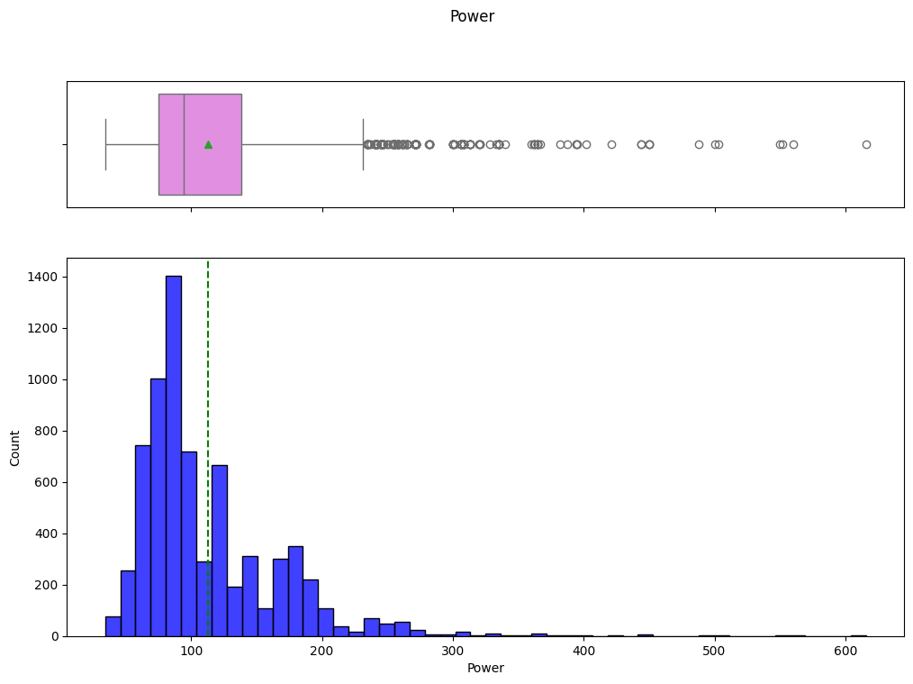

```python
histogram_boxplot(clean_df['Power'], title = 'Power')
```

**Power_log**

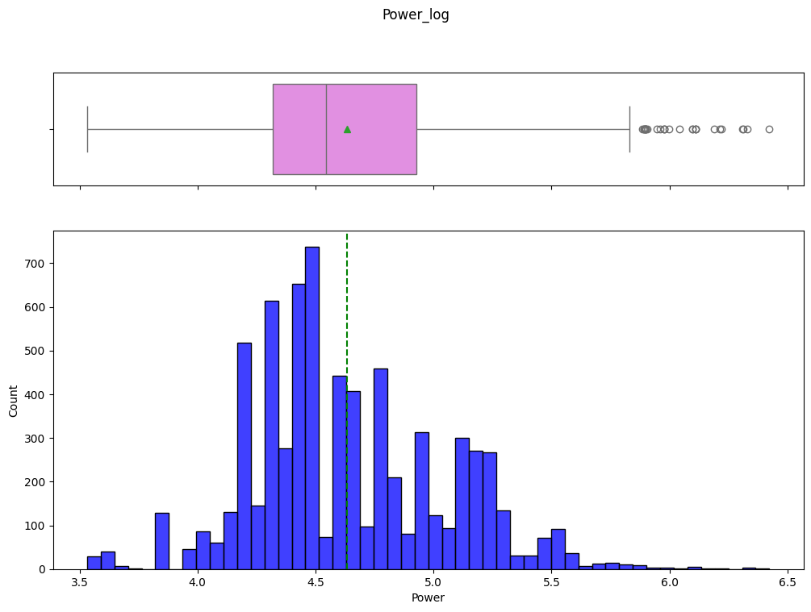

```python
Power_log = clean_df['Power']
histogram_boxplot(np.log(Power_log), title="Power_log")
```

- **Distribution Shape**: The histogram of the logarithmically transformed data appears more symmetric and bell-shaped, which is closer to a normal distribution. This transformation has effectively addressed the skewness by compressing the scale of higher values and expanding the lower values.
- **Boxplot Observations**: The boxplot for the log-transformed data also shows fewer extreme outliers, and the median is more centrally located within the box, indicating a more uniform spread of data.
- **Handling of Outliers**: The transformation has effectively minimized the influence of extreme outliers, which can improve the performance and accuracy of predictive models.
- Applying a logarithmic transformation to the "Power" variable is a good idea. This approach not only makes the data more amenable to analysis but can also lead to more robust, accurate, and generalizable models.

## 2.2 Categorical data

I pre-define a function to help with barplots that indicate the percentage for each category. This function takes the categorical column as the input and returns the barplots for the variable.

```python
def perc_on_bar(z):
    total = len(clean_df[z])  # Total number of data points
    plt.figure(figsize=(14, 7))

    # Get the actual counts of the categories in 'z'
    counts = clean_df[z].value_counts().reset_index()
    counts.columns = ['category', 'counts']  # Renaming for clarity

    # Create the count plot using 'category' for both x and hue, applying a colorful palette
    ax = sns.barplot(x='category', y='counts', hue='category', data=counts, palette='viridis', dodge=False)
    #ax.legend().set_visible(False)  # Hiding the legend

    for p in ax.patches:
        height = p.get_height()
        percentage = '{:.2f}%'.format(100 * height / total)
        x = p.get_x() + p.get_width() / 2
        y = height
        ax.annotate(percentage, (x, y), size=12, ha='center', va='bottom')

    plt.xticks(rotation=45)  # Rotate labels for better readability
    plt.show()
```

**Let us plot barplot for the `Location`. It will be helpful to know the number of percentage of cars from each city.**

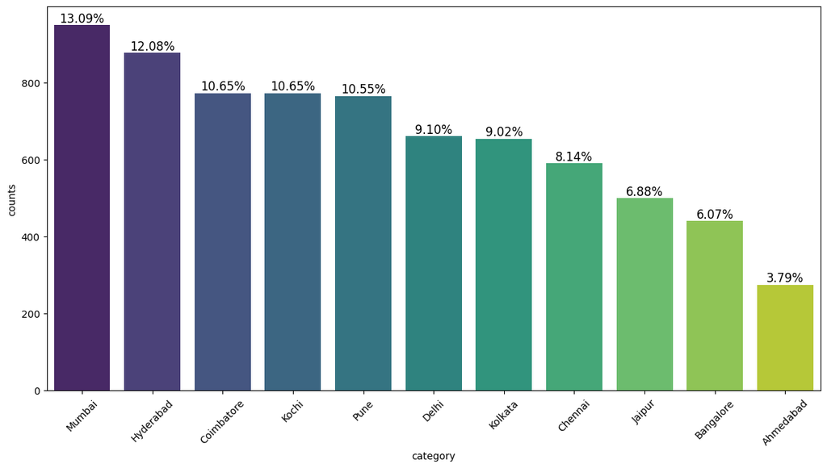

```python
perc_on_bar('Location')
```

**`Transmission`**

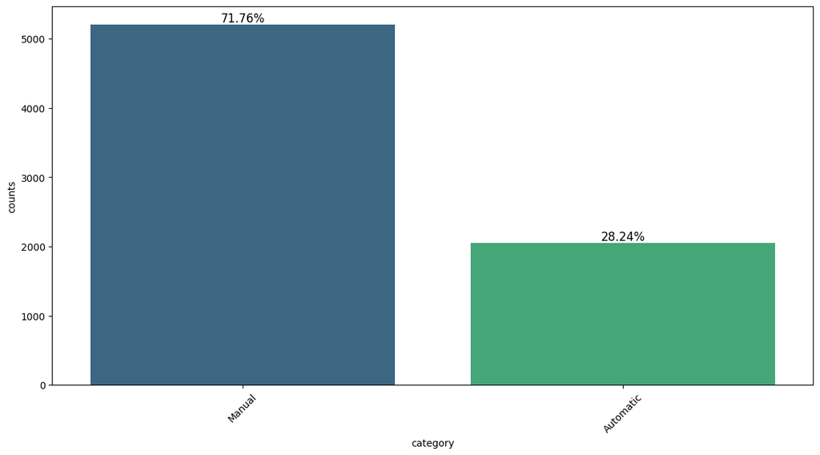

```python
perc_on_bar('Transmission')
```

**`Fuel`**

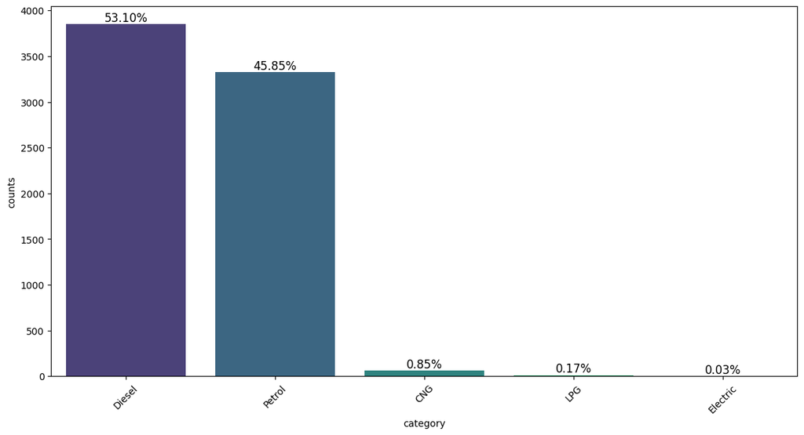

```python
perc_on_bar('Fuel')
```

# **3. Multivariate analysis**

### **3.1 Scatter plot**

A scatter plot allows us to see relationships between two variables.

**Pair plot for the 'Year' and 'Price'**

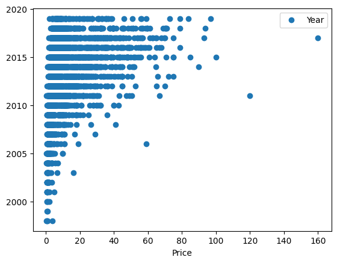

```python
clean_df.plot(x = 'Price', y = 'Year', style = 'o')
```

### **3.2 Heat map**

Heat map shows a 2D correlation matrix between numerical features.

- We notice that Price has a strong positive corrlation with New_price, Power and Engine
- Price also has a negative correlation with Mileage and KM_driven
- We also notice strong dependancies between Engine, Power and Mileage that we can use in our data imputation

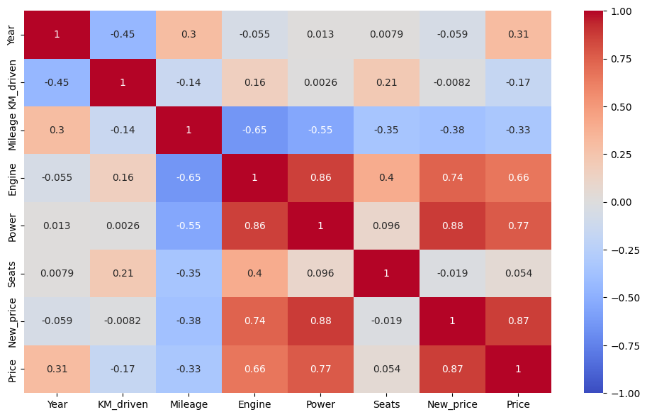

```python
plt.figure(figsize=(12, 7))
numeric_cols = clean_df.select_dtypes(include=[np.number])
sns.heatmap(numeric_cols.corr(), annot=True, vmin=-1, vmax=1, cmap='coolwarm')  # Added a color map for better visualization
plt.show()
```

### **3.3 Box plot - Location**

```python
def boxplot(z):
    plt.figure(figsize = (12, 5)) # Setting size of boxplot
    sns.boxplot(x = z, y = clean_df['Price']) # Defining x and y
    plt.show()
    plt.figure(figsize = (12, 5))
    plt.title('Without Outliers')
    sns.boxplot(x = z, y = clean_df['Price'], showfliers = False) # Turning off the outliers
    plt.show()
```

#### Let us now plot bivariate analysis of target variable with a categorical variable 'Location'

**Box Plot: Price vs Location**

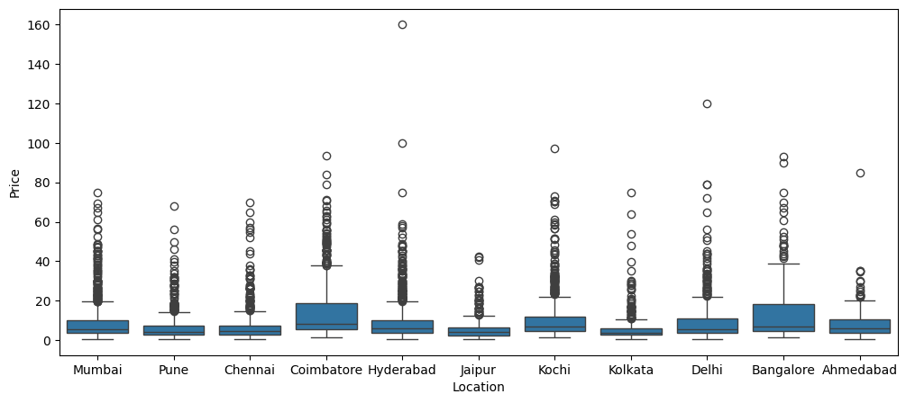

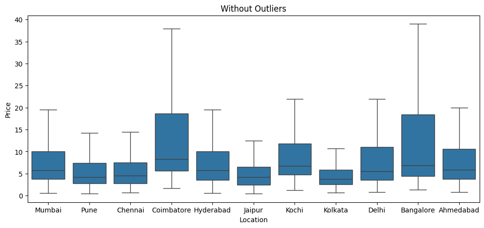

```python
boxplot(clean_df['Location'])
```

# **4. Feature Engineering**

1. First I filter out the rows where price data is not available. For model construction we only need entries with the Price value is available. Otherwise we cannot evaluate the performance of the model.
2. Then, I extract the Brand and Model data from the Name variable
3. Impute the missing `Mileage` values based on the average mileage value of cars with similar Brand, Model and Engine
4. Impute the missing `Seats` values based on the average value of cars with similar Brand and Model
5. Impute the missing `Engine` values based on the average of cars with similar Brand, Model and Mileage
6. Impute the missing `Power` values based on the average of cars with similar Brand, Model and Engine
7. Drop the `New_price` variable, because of too many missing values.

```python
output_df = clean_df.dropna(subset=['Price']).copy() # remove rows where the 'Price' value is missing
print("Remaining NaN in 'Price':", output_df['Price'].isna().sum()) # verify changes
```

```
Remaining NaN in 'Price': 0
```

Checking for missing values in each column:

```python
output_df.isnull().sum()
```

```
Name               0
Location           0
Year               0
KM_driven          0
Fuel               0
Transmission       0
Owner              0
Mileage           70
Engine            36
Power            143
Seats             42
New_price       5194
Price              0
dtype: int64
```

### `Name` variable

- The `Name` column in the current format would not be very useful in our analysis.
- With 2041 unique names, car names are not going to be great predictors of the price in our current data. * These entries carry additional information about fuel type, seats that is repeted in other columns
- However, we can process this column to extract car 'Brand' and 'Model' from the 'Name' variable. It will help our analysis down the road.
- Example entries in the 'Name' column:
  - Toyota Innova 2.5 G4 Diesel 8-seater
  - Mercedes-Benz New C-Class C 250 CDI Elegance
  - BMW 3 Series 320d
  - Hyundai i20 Magna 1.4 CRDi (Diesel)
  - Mercedes-Benz New C-Class C 250 CDI Elegance
  - Maruti SX4 Green Vxi (CNG)
  - Hyundai Verna XXi ABS (Petrol)

**Changes:**

- Clean the 'Name' variable
- Derive new 'Brand' and 'Model' variables from 'Name'
- Rearrange the order of columns for better efficiency

We know that we have missing values in the Seats column. So, we check if we can fill in the missing Seats values based on the information in 'Name' column. We check for rows where 'Name' contains *seater* (case insensitive) and the corresponding value under 'Seats' is missing. Since the output is 0, we cannot fill in missing values under Seats based on Name.

```python
seater_df = output_df[output_df['Name'].str.contains('Seater', case=False, na=False) & output_df['Seats'].isnull()]
print('Number of rows where Name contains Seater and value is missing in Seats column:', len(seater_df))
```

```
Number of rows where Name contains Seater and value is missing in Seats column: 0
```

Filter rows where 'Name' contains 'new' (case insensitive) and 'Owner_type' is not 'First'. We see that there are many cars where the owner is not *First* and the production year goes back to *2011* or *2013*, but the 'Name' contains *new*. So, some of the information in the Name variable is inaccurate.

```python
owner_df = output_df[(output_df['Name'].str.contains('new', case=False, na=False)) & (output_df['Owner'] != 'First')]
owner_df.head(10)
```

|  | Name | Location | Year | KM_driven | Fuel | Transmission | Owner | Mileage | Engine | Power | Seats | New_price | Price |
| --- | --- | --- | --- | --- | --- | --- | --- | --- | --- | --- | --- | --- | --- |
| 4 | Audi A4 New 2.0 TDI Multitronic | Coimbatore | 2013 | 40670 | Diesel | Automatic | Second | 15.20 | 1968.0 | 140.80 | 5.0 | NaN | 17.74 |
| 63 | Mercedes-Benz New C-Class 200 CDI Classic | Pune | 2011 | 65000 | Diesel | Manual | Second | 15.80 | 2148.0 | 170.00 | 5.0 | NaN | 10.00 |
| 265 | Mercedes-Benz New C-Class C 220 CDI CLASSIC | Bangalore | 2014 | 57000 | Diesel | Manual | Second | 15.80 | 2148.0 | 170.00 | 5.0 | NaN | 18.00 |
| 426 | Mercedes-Benz New C-Class C 200 CGI Avantgarde | Mumbai | 2011 | 50000 | Petrol | Automatic | Second | 11.74 | 1796.0 | 186.00 | 5.0 | NaN | 8.50 |
| 887 | Mercedes-Benz New C-Class C 200 CGI | Mumbai | 2011 | 48000 | Petrol | Automatic | Second | 14.74 | 1991.0 | 184.00 | 5.0 | NaN | 9.75 |
| 1027 | Tata New Safari DICOR 2.2 EX 4x2 | Delhi | 2011 | 77000 | Diesel | Manual | Second | 11.57 | 2179.0 | 138.10 | 7.0 | NaN | 3.50 |
| 1239 | Mercedes-Benz New C-Class C 220d Avantgarde Ed... | Mumbai | 2013 | 87000 | Diesel | Automatic | Second | 19.27 | 2143.0 | 167.62 | 5.0 | NaN | 17.00 |
| 1356 | Mercedes-Benz New C-Class C250 Avantgarde | Mumbai | 2011 | 45000 | Petrol | Automatic | Second | 11.74 | 1796.0 | 186.00 | 5.0 | NaN | 13.50 |
| 1446 | Mercedes-Benz New C-Class 200 Kompressor | Hyderabad | 2010 | 65000 | Petrol | Manual | Second | 11.70 | 1796.0 | 178.00 | 5.0 | NaN | 11.75 |
| 1502 | Mercedes-Benz New C-Class C 200 CGI Avantgarde | Mumbai | 2011 | 40000 | Petrol | Automatic | Second | 11.74 | 1796.0 | 186.00 | 5.0 | NaN | 14.50 |

**Clean the 'Name' column:**

```python
def clean_name(name):
    # Remove 'New' and any of the specified fuel types, case insensitive, possibly within brackets
    name = re.sub(r'\bnew\b', '', name, flags=re.IGNORECASE)
    name = re.sub(r'\b(cng|diesel|petrol|lpg|electric)\b', '', name, flags=re.IGNORECASE)
    name = re.sub(r'\s*\((cng|diesel|petrol|lpg|electric)\)\s*', '', name, flags=re.IGNORECASE)
    # Replace number followed by 'Series' with a hyphen in between
    name = re.sub(r'(\d+)\s+(series)', r'\1-\2', name, flags=re.IGNORECASE)
    # Remove number and 'seater'
    name = re.sub(r'\d+-seater', '', name, flags=re.IGNORECASE)
    name = re.sub(r'\d+\s+seater', '', name, flags=re.IGNORECASE)
    # Remove all instances of parentheses
    name = re.sub(r'[()]', '', name)
    # Additional cleaning to strip extra spaces and correct the formatting
    name = re.sub(r'\s+', ' ', name).strip()

    return name

output_df['Cleaned_Name'] = output_df['Name'].apply(clean_name)
```

```python
# Extract the first and second words for Brand and Model
output_df['Brand'] = output_df['Cleaned_Name'].str.split().str.get(0)
output_df['Model'] = output_df['Cleaned_Name'].str.split().str.get(1)
```

### `Mileage` variable

```python
# Calculate the mean 'Mileage' for each 'Brand', 'Model', 'Engine' group, excluding zeros and NaNs
group_means = output_df[(output_df['Mileage'] != 0) & (output_df['Mileage'].notna())].groupby(['Brand', 'Model', 'Engine'])['Mileage'].mean()

# If 'Engine' is missing use only Mileage
brand_model_means = output_df[(output_df['Mileage'] != 0) & (output_df['Mileage'].notna())].groupby(['Brand', 'Model'])['Mileage'].mean()
overall_mean = output_df[(output_df['Mileage'] != 0) & (output_df['Mileage'].notna())]['Mileage'].mean()

# Apply the corrected mileage values
def get_corrected_mileage(row):
    if row['Mileage'] == 0 or np.isnan(row['Mileage']):
        if pd.notna(row['Engine']):
            # Try to get the group mean, if unavailable, fallback to brand/model mean, then overall mean
            return group_means.get((row['Brand'], row['Model'], row['Engine']),
                                   brand_model_means.get((row['Brand'], row['Model']), overall_mean))
        else:
            # Fallback to brand/model mean, then overall mean
            return brand_model_means.get((row['Brand'], row['Model']), overall_mean)
    else:
        return row['Mileage']

output_df['Mileage'] = output_df.apply(get_corrected_mileage, axis=1)

print(f'Remaining rows with zero Mileage: {output_df[output_df["Mileage"] == 0].shape[0]}')
print(f'Missing values in Mileage after update: {output_df["Mileage"].isna().sum()}')
```

```
Remaining rows with zero Mileage: 0
Missing values in Mileage after update: 0
```

### `Seats` variable

- Now, we can use the information in Brand and Model columns to impute the missing values.
- We will replace the missing`Seats` values with the median of cars with similar Brand and Model.

```python
def impute_seats(series):
    if series.isna().all():
        return series  # Return the series as is if all values are NaN
    else:
        return series.fillna(series.median())

output_df['Seats'] = output_df.groupby(['Brand', 'Model'])['Seats'].transform(impute_seats)
seats_na = output_df[output_df['Seats'].isna()]
```

Now we have only 3 rows with missing seat value. When we list these rows, we see that Brand+Model for all three rows is Maruti Estilo. These car models are 5 seaters, so we can simple replace the remaining missing values with 5.

```python
# Print the entries with NaN 'Seats'
print("Entries with NaN 'Seats':")
seats_na
```

```
Entries with NaN 'Seats':
```

|  | Name | Location | Year | KM_driven | Fuel | Transmission | Owner | Mileage | Engine | Power | Seats | New_price | Price | Cleaned_Name | Brand | Model |
| --- | --- | --- | --- | --- | --- | --- | --- | --- | --- | --- | --- | --- | --- | --- | --- | --- |
| 2369 | Maruti Estilo LXI | Chennai | 2008 | 56000 | Petrol | Manual | Second | 19.5 | 1061.0 | NaN | NaN | NaN | 1.50 | Maruti Estilo LXI | Maruti | Estilo |
| 3882 | Maruti Estilo LXI | Kolkata | 2010 | 40000 | Petrol | Manual | Second | 19.5 | 1061.0 | NaN | NaN | NaN | 2.50 | Maruti Estilo LXI | Maruti | Estilo |
| 5893 | Maruti Estilo LXI | Chennai | 2008 | 51000 | Petrol | Manual | Second | 19.5 | 1061.0 | NaN | NaN | NaN | 1.75 | Maruti Estilo LXI | Maruti | Estilo |

```python
#Maruti Estilo can accomodate 5
output_df["Seats"] = output_df["Seats"].fillna(5.0)
```

### `Engine` column

- We impute these missing values based on the average value of cars with similar Brand, Model and Mileage.
  - As we know cars with similar Brand+Model, Mileage tend to have similar engines.
  - If a specific Brand + Model + Mileage group is not available, then I use only Brand + Model average
  - There are 36 missing values in the Engine column
- To improve the distribution of values, we apply log transformation to Engine column as well

```python
# Calculate the mean 'Engine' for each 'Brand', 'Model', 'Mileage' group
engine_means = output_df[output_df['Engine'].notna()].groupby(['Brand', 'Model', 'Mileage'])['Engine'].mean()
# use only 'Brand' + 'Model', if 'Mileage' is missing or the specific group mean is not available
brand_model_engine_means = output_df[output_df['Engine'].notna()].groupby(['Brand', 'Model'])['Engine'].mean()

def get_corrected_engine(row):
    if pd.isna(row['Engine']):
        # Try to get the group mean based on Brand, Model, Mileage; if unavailable, fallback to Brand, Model
        return engine_means.get((row['Brand'], row['Model'], row['Mileage']),
                                brand_model_engine_means.get((row['Brand'], row['Model']), np.nan))
    else:
        return row['Engine']

output_df['Engine'] = output_df.apply(get_corrected_engine, axis=1)

remaining_missing_engine = output_df['Engine'].isna().sum()
print(f'Remaining missing values in Engine column: {remaining_missing_engine}')
```

```
Remaining missing values in Engine column: 0
```

### `Power` variable

```python
# Calculate mean 'Power' for different groupings
power_means_engine = output_df[output_df['Power'].notna()].groupby(['Brand', 'Model', 'Engine'])['Power'].mean()
power_means_model_engine = output_df[output_df['Power'].notna()].groupby(['Model', 'Engine'])['Power'].mean()
power_means_model = output_df[output_df['Power'].notna()].groupby(['Model'])['Power'].mean()
power_means_mileage = output_df[output_df['Power'].notna()].groupby(['Mileage'])['Power'].mean()

def get_corrected_power(row):
    if pd.isna(row['Power']):
        # Try to get the group mean based on Brand, Model, Engine
        power_with_engine = power_means_engine.get((row['Brand'], row['Model'], row['Engine']), np.nan)
        if pd.isna(power_with_engine):
            # Try Model + Engine
            power_model_engine = power_means_model_engine.get((row['Model'], row['Engine']), np.nan)
            if pd.isna(power_model_engine):
                # Try Model only
                power_model = power_means_model.get(row['Model'], np.nan)
                if pd.isna(power_model):
                    # Finally, use Mileage
                    return power_means_mileage.get(row['Mileage'], np.nan)
                else:
                    return power_model
            else:
                return power_model_engine
        else:
            return power_with_engine
    else:
        return row['Power']

output_df['Power'] = output_df.apply(get_corrected_power, axis=1)

remaining_missing_power = output_df['Power'].isna().sum()
print(f'Remaining missing values in Power column: {remaining_missing_power}')
```

```
Remaining missing values in Power column: 0
```

### `New_price` valriable

```python
# Calculate the mean 'New_price' for each 'Brand', 'Model', 'Year' group
new_price_means = output_df[output_df['New_price'].notna()].groupby(['Brand', 'Model', 'Year'])['New_price'].mean()

def get_corrected_new_price(row):
    if pd.isna(row['New_price']):
        # Try to get the group mean based on Brand, Model, Year
        return new_price_means.get((row['Brand'], row['Model'], row['Year']), np.nan)
    else:
        return row['New_price']

output_df['New_price'] = output_df.apply(get_corrected_new_price, axis=1)

remaining_missing_new_price = output_df['New_price'].isna().sum()
print(f'Remaining missing values in New_price column: {remaining_missing_new_price}')
```

```
Remaining missing values in New_price column: 3153
```

Creating log transformations

```python
output_df["KM_driven_log"] = np.log(output_df["KM_driven"])
output_df["Price_log"] = np.log(output_df["Price"])
output_df["Engine_log"] = np.log(output_df["Engine"])
output_df["Power_log"] = np.log(output_df["Power"])
output_df["Mileage_log"] = np.log(output_df["Mileage"])
```

```python
clean_order = ['Name', 'Year', 'Owner', 'KM_driven', 'Fuel',
             'Engine', 'Power', 'Mileage', 'Transmission', 'Seats', 'Location',
             'New_price', 'Price']
clean_df = clean_df[clean_order]
clean_df.head()
```

|  | Name | Year | Owner | KM_driven | Fuel | Engine | Power | Mileage | Transmission | Seats | Location | New_price | Price |
| --- | --- | --- | --- | --- | --- | --- | --- | --- | --- | --- | --- | --- | --- |
| 0 | Maruti Wagon R LXI CNG | 2010 | First | 72000 | CNG | 998.0 | 58.16 | 26.60 | Manual | 5.0 | Mumbai | NaN | 1.75 |
| 1 | Hyundai Creta 1.6 CRDi SX Option | 2015 | First | 41000 | Diesel | 1582.0 | 126.20 | 19.67 | Manual | 5.0 | Pune | NaN | 12.50 |
| 2 | Honda Jazz V | 2011 | First | 46000 | Petrol | 1199.0 | 88.70 | 18.20 | Manual | 5.0 | Chennai | 8.61 | 4.50 |
| 3 | Maruti Ertiga VDI | 2012 | First | 87000 | Diesel | 1248.0 | 88.76 | 20.77 | Manual | 7.0 | Chennai | NaN | 6.00 |
| 4 | Audi A4 New 2.0 TDI Multitronic | 2013 | Second | 40670 | Diesel | 1968.0 | 140.80 | 15.20 | Automatic | 5.0 | Coimbatore | NaN | 17.74 |

# **5. Conclusion**

Now we have a clean data set with informative variables, adjusted distributions and no missing values.

```python
output_order = ['Brand', 'Model', 'Year', 'Owner', 'KM_driven_log', 'Fuel', 'Engine_log',
                'Power_log', 'Mileage_log', 'Transmission', 'Seats', 'Location', 'Price_log']
output_df = output_df[output_order]
output_df.head()
```

|  | Brand | Model | Year | Owner | KM_driven_log | Fuel | Engine_log | Power_log | Mileage_log | Transmission | Seats | Location | Price_log |
| --- | --- | --- | --- | --- | --- | --- | --- | --- | --- | --- | --- | --- | --- |
| 0 | Maruti | Wagon | 2010 | First | 11.184421 | CNG | 6.905753 | 4.063198 | 3.280911 | Manual | 5.0 | Mumbai | 0.559616 |
| 1 | Hyundai | Creta | 2015 | First | 10.621327 | Diesel | 7.366445 | 4.837868 | 2.979095 | Manual | 5.0 | Pune | 2.525729 |
| 2 | Honda | Jazz | 2011 | First | 10.736397 | Petrol | 7.089243 | 4.485260 | 2.901422 | Manual | 5.0 | Chennai | 1.504077 |
| 3 | Maruti | Ertiga | 2012 | First | 11.373663 | Diesel | 7.129298 | 4.485936 | 3.033510 | Manual | 7.0 | Chennai | 1.791759 |
| 4 | Audi | A4 | 2013 | Second | 10.613246 | Diesel | 7.584773 | 4.947340 | 2.721295 | Automatic | 5.0 | Coimbatore | 2.875822 |

Check for missing values

```python
output_df.isnull().sum()
```

```
Brand            0
Model            0
Year             0
Owner            0
KM_driven_log    0
Fuel             0
Engine_log       0
Power_log        0
Mileage_log      0
Transmission     0
Seats            0
Location         0
Price_log        0
dtype: int64
```

### **Saving the Data**

I save the pre-processed dataset into a separate file. I will load this data set in the next notebook to use for model construction. As a back-up, I'm also saving the original data and cleaned data with all variables into separate sheets in the same Excel file

```python
with pd.ExcelWriter('Used_cars_final.xlsx', engine='openpyxl') as writer:
    output_df.to_excel(writer, sheet_name='Final Data', index = False)
    clean_df.to_excel(writer, sheet_name='Cleaned Data', index= False)
    input_df.to_excel(writer, sheet_name='Original Data', index = False)
```